# Task5

Redkokosh Kirill

11/24/2021

```r
df <- read.table('bakery.dat', header = TRUE, sep="\t")
head(df)
```

```
##                  X Energy Protein  Fat Total.Carbo Sugars Fibre Sodium
## 1     Banana.Bread    859     3.8  1.8        44.2   22.7   1.6    306
## 2    Banana.Muffin   1015     4.5  4.0        47.9   24.6   1.9    331
## 3     Bavarian.Rye   1029    11.0  1.3        46.7    0.5   6.0    293
## 4        Bun.Dough    883     7.2  4.5        35.4    6.3   2.2    611
## 5      Carrot.Cake   1423     4.9 17.4        42.3   28.7   2.8    295
## 6 Carrot.Cake.Iced   1490     4.4 18.4        46.9   34.4   2.2    287
##   Potassium
## 1       161
## 2       181
## 3       234
## 4       126
## 5       296
## 6       240
```

```r
summary(df[-1])
```

```
##      Energy        Protein            Fat          Total.Carbo
##  Min.   : 839   Min.   : 3.300   Min.   : 1.300   Min.   :29.00
##  1st Qu.:1013   1st Qu.: 7.200   1st Qu.: 2.100   1st Qu.:38.80
##  Median :1051   Median : 8.200   Median : 4.000   Median :45.30
##  Mean   :1081   Mean   : 8.372   Mean   : 5.648   Mean   :43.48
##  3rd Qu.:1126   3rd Qu.:10.500   3rd Qu.: 7.700   3rd Qu.:47.60
##  Max.   :1490   Max.   :12.400   Max.   :18.400   Max.   :52.70
##      Sugars           Fibre           Sodium        Potassium
##  Min.   : 0.100   Min.   :1.300   Min.   :287.0   Min.   :100.0
##  1st Qu.: 0.300   1st Qu.:2.200   1st Qu.:331.0   1st Qu.:136.0
##  Median : 1.900   Median :2.600   Median :495.0   Median :182.0
##  Mean   : 8.036   Mean   :3.372   Mean   :488.5   Mean   :191.6
##  3rd Qu.:11.900   3rd Qu.:4.600   3rd Qu.:567.0   3rd Qu.:235.0
##  Max.   :34.400   Max.   :7.100   Max.   :973.0   Max.   :321.0
```

##Коротко о данных:

Данные о 25 хлебобулочных продуктах из пекарни Brumby’s. Даны 8 харатеристик для каждого:

Энергия (в килоджоулях)

Белок (в граммах)

Жир (в граммах)

Всего углеводов (в г)

Сахар (в граммах)

Пищевые волокна (в граммах)

Натрий (в миллиграммах)

Калий (в миллиграммах)

В связи со сложностями в интерпретации натрия и каоия уберем их из рассмотрения.

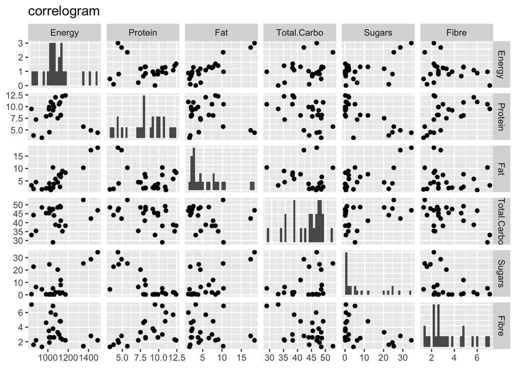

```r
library(lattice)
library(ggplot2)
library('GGally')
ggpairs(df, title="correlogram", columns=c(2:7), upper = list(continuous = "points"), diag = list(continuous = "barDiag"))
```

Не будем логорифмировать данные или каким-либо ещё образом их предобрабатывать. На outliers посмотрим на графике $\mathsf{Z}$.

Так как признаки измерены в разных шкалах, то их необходимо стандартизоавть.

```r
library("factoextra")
library("FactoMineR")
res.pca <- PCA(df[c(-1,-8,-9)], scale.unit = TRUE, ncp = 3, graph= FALSE)
get_eigenvalue(res.pca)
```

```
##        eigenvalue variance.percent cumulative.variance.percent
## Dim.1 2.930683328      48.84472213                    48.84472
## Dim.2 1.667899958      27.79833263                    76.64305
## Dim.3 0.751237667      12.52062779                    89.16368
## Dim.4 0.539305872       8.98843121                    98.15211
## Dim.5 0.106562562       1.77604269                    99.92816
## Dim.6 0.004310613       0.07184356                   100.00000
```

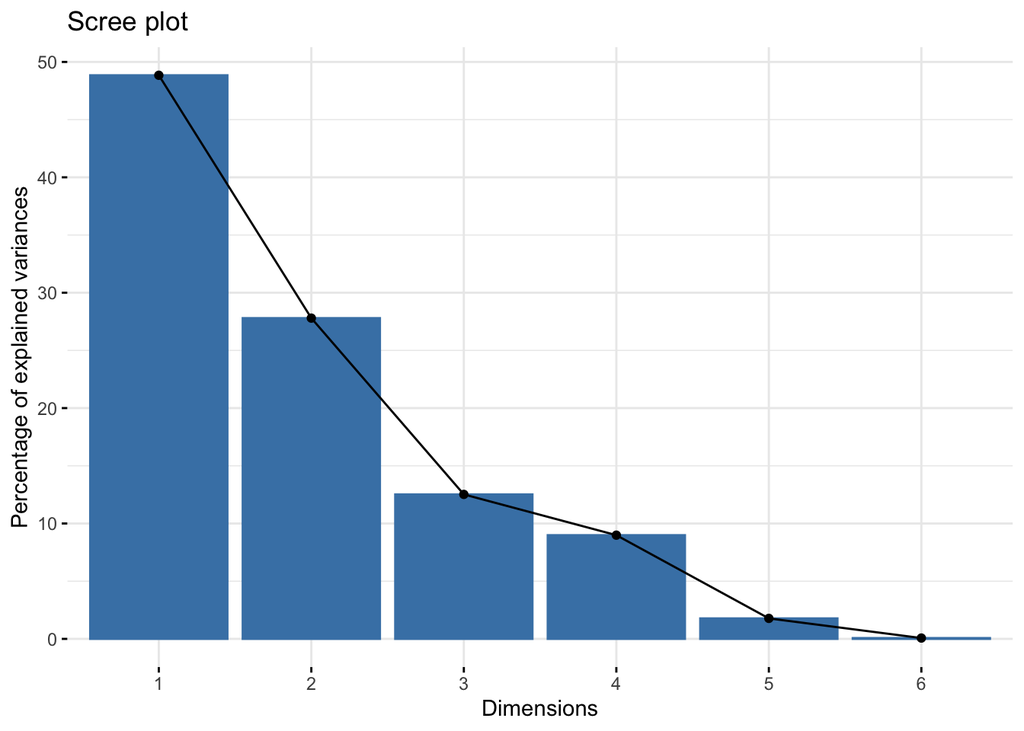

```r
fviz_eig(res.pca)
```

Сумма собственных чисел = количеству признаков, значит АГК по корреляционной матрице (scale.unit = TRUE).

Информативность первых 2 главных компонент более 75%. На первые 3 компоненты приходится около 90%, поэтому будем интерпретировать 3 компоненты (попробуем, по крайней мере).

Для интерпретации главных компонент рассмотрим матрицу $\mathsf{U}$ (столбцы соответсвуют векторам $U_1,...,U_3$).

```r
res.pca$svd$V
```

```
##            [,1]        [,2]        [,3]
## [1,]  0.4328591  0.39142223  0.49899556
## [2,] -0.4243510  0.35173180  0.53660860
## [3,]  0.3943578  0.56176942 -0.02764046
## [4,]  0.2658413 -0.51733778  0.56046634
## [5,]  0.5272869  0.05384736 -0.34940582
## [6,] -0.3582430  0.37006835 -0.16150451
```

Первая компонента – разница между “энергетической составляющей” (энергия+жир+углеводы+сахар) и “полезной” (белок+пищевые волокна).

Вторая – разница между всеми составляющими и углеводами.

Третья – энергия+белок+углеводы - (сахар+пищевые волокна).

Рассмотрим диаграмму факторных весов (для первых двух компонент) – $\mathsf{F}$ (сумма квадратов по $i$-ому столбцу равна $\lambda_i$).

```r
head(get_pca_var(res.pca)$coord, 8)
```

```
##                  Dim.1       Dim.2       Dim.3
## Energy       0.7410219  0.50551086  0.43249925
## Protein     -0.7264565  0.45425177  0.46509997
## Fat          0.6751106  0.72550949 -0.02395709
## Total.Carbo  0.4551000 -0.66812726  0.48577841
## Sugars       0.9026750  0.06954236 -0.30284388
## Fibre       -0.6132848  0.47793291 -0.13998236
```

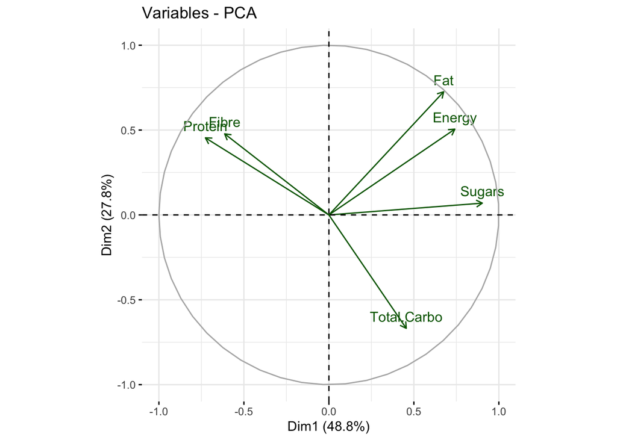

```r
fviz_pca_var(res.pca, col.var = "darkgreen")
```

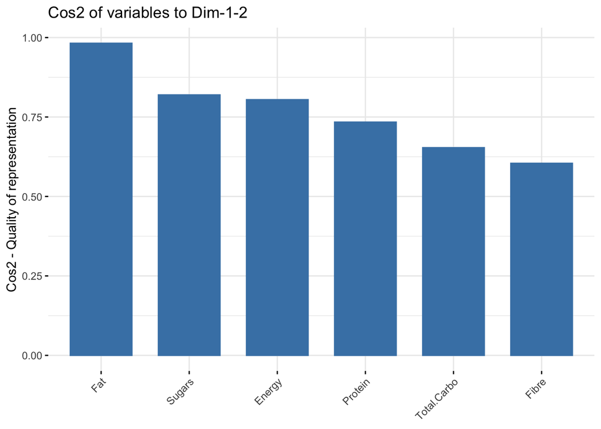

```r
fviz_cos2(res.pca, choice = "var", axes = 1:2)
```

Длина всех векторов близка к 1, это значит, что все эти признаки хорошо описываются 2 первыми главными компонентами. Для подтверждения рассмотрим также $cos^2(\angle(X_i, V_j)) = f_{ij}^2 = cor_{i,j}^2$ этих векторов.

Рассмотрим матрицу главных компонент – $\mathsf{Z}$ и её визуализацию.

```r
head(res.pca$ind$coord)
```

```
##        Dim.1       Dim.2       Dim.3
## 1  0.9161695 -2.04803683 -1.87052732
## 2  1.6367118 -1.53635855 -0.96007613
## 3 -1.7448619 -0.04938602  0.69195253
## 4 -0.6752468 -0.35579344 -1.49526694
## 5  3.6394979  1.94560045 -0.38631239
## 6  4.6219028  1.65433577  0.04675813
```

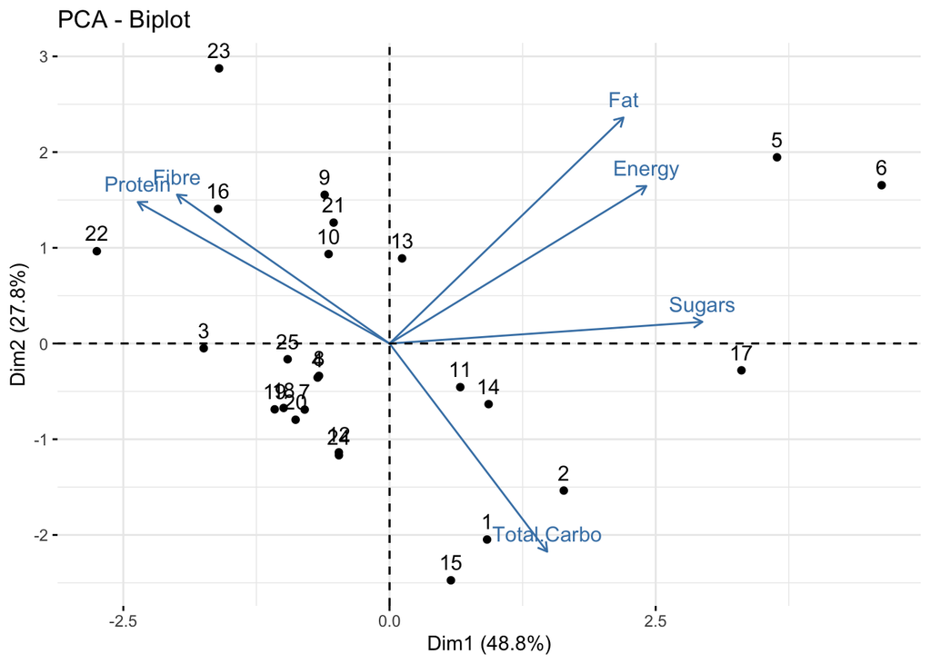

```r
fviz_pca_biplot(res.pca)
```

Стрелочки – проекции ортов. Рассматривая индивида необходимо смотреть на то с какой стороны относительно стрелочки какого-либо признака он находится. Например, рассмотрим морковный кекс (под номером 5), согласно графику у него должны быть большие значения Enegry, Fat, Sugars (они и вправду близки к максимальным по выборке), среднее значение Total.Carbo (почти mean по выборке) и значения ниже среднего Fibre, Protein (так и есть).

Рассмотрим также индивида под номером 23– медовый хлеб с семечками, много пищевых волокон (близко к максимуму по выборке), значения выше среднего– белок и жиры (по выборке– примерно значение 3 квартиля), среднее значение– энергии (совпадает со средним значением по выборке), меньше среднего– сахара (меньше среднего по выборке), минимальное количество углеводов (на самом деле минимум по выборке). Выделяется наименьшим показателем углеводов при этом имея достаточно высокие показатели почти всех других признаков (исключая сахара). С названием этого хлебобулочного изделия (медовый хлеб с семечками) выводы по АГК хорошо соотносятся.